# Exploring climate at specific locations with R

ENS-2000 Student practical

# Introduction

In this practical, you will extract climate information from a dataset of coordinates. You will map your sample locations, look at the climate values associated with them, compare two groups, and carry out a statistical test.

NOTE: This practical is designed to work on the web version of Rstudio on rstudio.bangor.ac.uk. If you feel strongly about running it locally, you will need to install the `pastclim` package and its dependencies.

## Choose a scenario

The same R workflow can be used for all three scenarios. Full worksheets are available on Blackboard.

**Forestry: comparing plantation types**  
A forestry organisation is comparing the climatic conditions of its timber-producing forests in northern and southern Europe to understand how forestry practices need to adapt to different environments, particularly in the face of future climate change. They want to know whether the plantation in the north experience a different average yearly precipitation than the plantations in the south. Compare locations of their plantations in Northern Europe with locations in Southern Europe using **BIO12 (annual precipitation)**.

**Zoology: comparing two animal species**  
In Europe, there are two species of grass snake: - the common grass snake (*Natrix natrix*), which is found in Eastern part of Europe, and the barred grass snake (*Natrix helvetica*), which is found in the western part of Europe. A zoologist wants to know whether these two animal species are recorded in places with different annual mean temperatures. Compare the groups using **BIO1 (annual mean temperature)**.

**Geography and conservation: protected and unprotected places**  
A conservation team wants to know whether the protected areas in Europe are a good representation of the general climate in Europe. Ideally, protected areas should be representative of the total climate in Europe, so that we capture the full range of conditions that species experience. Compare a selection of locations in European protected areas, with a random selection of unprotected areas to see if there is a difference in climate, specifically in terms of precipitation **BIO12 (annual precipitation)**

## Learning aims

By the end of the practical, you should be able to:

- read a table containing latitude and longitude;
- map geographical coordinates on a map of Europe;
- extract climate values for each location;
- carry out and interpret a statistical test;
- make a plot to compare the two groups

# Set up R

When you start R, you will need to load a few libraries. This will allow you to use the functions in `pastclim` and to plot maps. You only need to do this once per R session:

```r
# Load the packages
library(pastclim)
library(terra)
library(maps)
```

```r
# first, you need to set your data path. You only need to do this once. Type:
set_data_path()

# you will see the following message:

# The data_path will be set to /home/people/user/.local/share/R/pastclim.
# A copy of the Example dataset will be copied there.
# This path will be saved by pastclim for future use.
# Proceed?

# 1: Yes
# 2: No

# Selection:
# Enter an item from the menu, or 0 to exit

# Select 1 to proceed. You will only need to do this once, and the path will be saved for future use.

# NOTE: you do not need to do anything with the files at /home/people/user/.local/share/R/pastclim. They are in a hidden folder on the computer, where R can find them. You will use the `pastclim` functions to access the data.
```

# Load and inspect the sample coordinates

The coordinate file contains one row per sample. It has four columns:

| Column | Meaning |
| --- | --- |
| `sample` | A unique sample number |
| `lat` | Latitude in decimal degrees |
| `lon` | Longitude in decimal degrees |
| `group` | The group to which the sample belongs (A or B in the practice file, but will be different in your file) |

## Read the CSV file

This code is written using an example dataset `practice_samples.csv`. You need to download your chosen dataset from Blackboard and use the code to read it into R. Remember to change the name of your input files, and the names of the groups (`A` and `B` in this example). Make sure that the CSV file is in your working directory (check with `getwd()` and change with `setwd()`).

```r
# Read the CSV file into R by typing the following command:
samples <- read.csv("practice_samples.csv")

# Look at the first rows
head(samples)
```

```
##   sample  lat lon group
## 1      1 55.0  -4     A
## 2      2 53.0  -2     A
## 3      3 52.0   0     A
## 4      4 50.5   2     A
## 5      5 48.0   4     A
## 6      6 49.0   7     A
```

```r
# Check the number of rows (= number of samples)
nrow(samples)
```

```
## [1] 24
```

**Questions** *(no need to report the answers, but think about them before moving on)*

1. How many sample locations are there?
2. What are the names of the columns?
3. How many samples are in each group (hint: try `sum(samples$group == "A")`)?

# Map the sample locations

A map helps us check where the sample locations are and whether the two groups are geographically separated.

First, we extract the two groups into separate data frames so that we can plot each using different colours. Then we can plot the sample locations on a map of Europe. Remember to change the label A and B to the names of your groups.

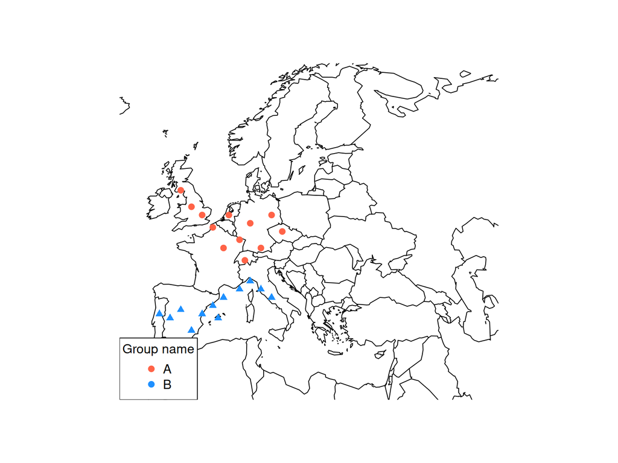

```r
# first extract the two groups into separate data frames filtering for either "A" or "B" in the group column.
# REMEMBER TO CHANGE THE LABELS A AND B TO THE NAMES OF YOUR GROUPS
samples_A <- subset(samples, group == "A")
samples_B <- subset(samples, group == "B")


# plot the map first
# The xlim and ylim arguments crop the map to the area of interest (in this case, Europe)
map("world", xlim = c(-15, 55), ylim = c(30, 70))

# add sample locations for group A (as red circles)
points(samples_A$lon, samples_A$lat, pch = 19, col = "tomato")

# add sample locations for group B (as blue triangles)
points(samples_B$lon, samples_B$lat, pch = 17, col = "dodgerblue")

# Remember to change the labels "A" and "B" to the names of your groups
legend("bottomleft", legend = c("A", "B"), pch = 19, col = c("tomato", "dodgerblue"), title = "Group name")
```

**Questions** *(no need to report the answers, but think about them before moving on)*

1. Where are the samples located?
2. Are the two groups found in the same places, or are they geographically separated?
3. Should we expect a difference in climate?

# Extract climate for each sample location

We will now use the function `location_slice()` to extract climate values for the sample coordinates.

We will extract either “bio01” or “bio12”. BIO1 is the annual mean temperature, and BIO12 is the annual precipitation. You will focus on just one variable for your statistical comparison, depending on which scenario you chose. In this example, it’s `bio01`.

```r
climate_data <- location_slice(
  x = samples,                # data frame containing the coordinates and group information
  coords = c("lon", "lat"),   # names of the columns containing the coordinates
  time_bp = 0,                # time slice to extract (0 = present-day)
  bio_variables = "bio01",    # climate variable to extract (bio01 or bio12)
  dataset = "Example"         # climate dataset (this is always "Example" for this practical)
)
```

We can now look at the temperature `bio01` or precipitation `bio12` for each sample location. Each row corresponds to one sample location.

```r
# Look at the climate values
summary(climate_data$bio01)
```

```
##    Min. 1st Qu.  Median    Mean 3rd Qu.    Max.
##   2.476   9.035  10.736  11.010  14.252  15.918
```

You can now use these values to compare the two groups, in the same way as you have done in previous practicals. See the worksheet on Blackboard for further exercises.

# Next steps

Go to [Blackboard](https://blackboard.bangor.ac.uk) and follow the rest of the instructions on the worksheet

- plot data
- perform statistical test
- interpret results